# Untersuchungen der Wahlprogramme zur Bundestagswahl

Anina Klaus, Katja Konermann und Niklas Stepczynski

## Erste Schritte

Das Korpus wurde mithilfe der Bibliothek `quanteda` untersucht. Außerdem wird die Bibliothek `readtext` benötigt, um die Textdateien einlesen zu können. Für Topic Modelling wird zudem die Bibliothek `seededlda` verwendet.

```r
library(quanteda)
library(readtext)
library(seededlda)
```

Um das Korpus einlesen zu können, muss sich der Ordner `Korpus-Dateien` mit den Wahlprogrammen im aktuellen Arbeitsverzeichnis befinden. Die Namen der Dateien sind nach dem folgenden Muster aufgebaut: `<Wahl>-<Partei>-<Jahr>`. Das Wahlprogramm der CDU zur Bundestagswahl von 2017 ist zum Beispiel in der Datei `Bundestagswahl-CDU-2017` gespeichert. Mithilfe von `readtext` können aus den Dateinamen so Document Level Variables erstellt werden, die das Filtern nach Parteien und Jahren vereinfachen.  
Zusätzlich wird die Spalte `year` in numerische Werte konvertiert, um auch Vergleiche wie etwa Wahlprogramme vor 2009 zu ermöglichen.

```r
# Read in files and set document level variables
programs <- readtext("Korpus-Dateien",
                     docvarsfrom = "filenames",
                     docvarnames = c("type", "party", "year"),
                     dvsep = "-",
                     encoding="utf-8") %>% corpus()

# Convert characters in year column to integers
docvars(programs, field="year") <- as.integer(docvars(programs, field="year"))
```

```r
summary(programs)
```

```
## Corpus consisting of 27 documents, showing 27 documents:
##
##                                  Text Types Tokens Sentences           type        party year
##           Bundestagswahl-AfD-2013.txt   443    918        69 Bundestagswahl          AfD 2013
##           Bundestagswahl-AfD-2017.txt  5200  19054       889 Bundestagswahl          AfD 2017
##  Bundestagswahl-B90dieGruene-2002.txt  5727  26259      1465 Bundestagswahl B90dieGruene 2002
##  Bundestagswahl-B90dieGruene-2005.txt  6756  32651      1753 Bundestagswahl B90dieGruene 2005
##  Bundestagswahl-B90dieGruene-2009.txt 10380  58101      3126 Bundestagswahl B90dieGruene 2009
##  Bundestagswahl-B90dieGruene-2013.txt 13848  94691      5279 Bundestagswahl B90dieGruene 2013
##  Bundestagswahl-B90dieGruene-2017.txt 10931  69510      3924 Bundestagswahl B90dieGruene 2017
##           Bundestagswahl-CDU-2002.txt  5470  22862      1235 Bundestagswahl          CDU 2002
##           Bundestagswahl-CDU-2005.txt  3427  13011       804 Bundestagswahl          CDU 2005
##           Bundestagswahl-CDU-2009.txt  6091  30177      1791 Bundestagswahl          CDU 2009
##           Bundestagswahl-CDU-2013.txt  7663  46850      2525 Bundestagswahl          CDU 2013
##           Bundestagswahl-CDU-2017.txt  4620  21969      1290 Bundestagswahl          CDU 2017
##      Bundestagswahl-DIELINKE-2009.txt  5773  22382       853 Bundestagswahl     DIELINKE 2009
##      Bundestagswahl-DIELINKE-2013.txt  8491  43476      2308 Bundestagswahl     DIELINKE 2013
##      Bundestagswahl-DIELINKE-2017.txt 10700  64493      3872 Bundestagswahl     DIELINKE 2017
##           Bundestagswahl-FDP-2002.txt  7638  36097      1910 Bundestagswahl          FDP 2002
##           Bundestagswahl-FDP-2005.txt  5729  24048      1375 Bundestagswahl          FDP 2005
##           Bundestagswahl-FDP-2009.txt  8339  37862      2009 Bundestagswahl          FDP 2009
##           Bundestagswahl-FDP-2013.txt  7945  42573      2367 Bundestagswahl          FDP 2013
##           Bundestagswahl-FDP-2017.txt  7989  39710      2034 Bundestagswahl          FDP 2017
##           Bundestagswahl-PDS-2002.txt  4293  15660       755 Bundestagswahl          PDS 2002
##           Bundestagswahl-PDS-2005.txt  3026  10036       614 Bundestagswahl          PDS 2005
##           Bundestagswahl-SPD-2002.txt  5409  23711      1444 Bundestagswahl          SPD 2002
##           Bundestagswahl-SPD-2005.txt  3505  14014       911 Bundestagswahl          SPD 2005
##           Bundestagswahl-SPD-2009.txt  5888  30234      2065 Bundestagswahl          SPD 2009
##           Bundestagswahl-SPD-2013.txt  8349  47367      2560 Bundestagswahl          SPD 2013
##           Bundestagswahl-SPD-2017.txt  7546  41197      2404 Bundestagswahl          SPD 2017
```

Um das Korpus zu tokenisieren wird die `tokens`-Funktion von `quanteda` genutzt, wobei Satzzeichen und Stoppwörter entfernt werden. Die genutzten Stoppwörter sind in `quanteda` enthalten und umfassen folgende Token:

```r
stopwords("german")
```

```
##   [1] "aber"      "alle"      "allem"     "allen"     "aller"     "alles"     "als"
##   [8] "also"      "am"        "an"        "ander"     "andere"    "anderem"   "anderen"
##  [15] "anderer"   "anderes"   "anderm"    "andern"    "anderr"    "anders"    "auch"
##  [22] "auf"       "aus"       "bei"       "bin"       "bis"       "bist"      "da"
##  [29] "damit"     "dann"      "der"       "den"       "des"       "dem"       "die"
##  [36] "das"       "daß"       "derselbe"  "derselben" "denselben" "desselben" "demselben"
##  [43] "dieselbe"  "dieselben" "dasselbe"  "dazu"      "dein"      "deine"     "deinem"
##  [50] "deinen"    "deiner"    "deines"    "denn"      "derer"     "dessen"    "dich"
##  [57] "dir"       "du"        "dies"      "diese"     "diesem"    "diesen"    "dieser"
##  [64] "dieses"    "doch"      "dort"      "durch"     "ein"       "eine"      "einem"
##  [71] "einen"     "einer"     "eines"     "einig"     "einige"    "einigem"   "einigen"
##  [78] "einiger"   "einiges"   "einmal"    "er"        "ihn"       "ihm"       "es"
##  [85] "etwas"     "euer"      "eure"      "eurem"     "euren"     "eurer"     "eures"
##  [92] "für"       "gegen"     "gewesen"   "hab"       "habe"      "haben"     "hat"
##  [99] "hatte"     "hatten"    "hier"      "hin"       "hinter"    "ich"       "mich"
```

[output cut: 18 more lines]

Mit der `dfm`-Funktion von `quanteda` wird zudem eine Document-Feature-Matrix erstellt werden.

```r
# Create tokens object for whole corpus
program_toks <- tokens(programs,remove_punct = TRUE) %>% tokens_remove(stopwords("german"), padding = TRUE )
# Create dfm for corpus
program_dfm <- dfm(program_toks)
```

## Bag of Words

Mithilfe der Funktion `topfeatures` lassen sich aus einer `DFM` die n häufigsten Token extrahieren. Diese Token können auch mit `textplot_wordcloud` as Wortwolke dargestellt werden.

```r
topfeatures(program_dfm, n = 100)
```

```
##                            dass        menschen          müssen            mehr     deutschland
##          366206            3545            2979            2808            2738            2506
##           dafür         deshalb          setzen         stärken           sowie            neue
##            1657            1576            1351            1290            1247            1233
##          sollen    gesellschaft     unternehmen          unsere          arbeit         politik
##            1201            1185            1173            1118            1092            1049
##           leben           dabei        brauchen        schaffen         unserer         soziale
##            1029            1018            1012            1012             990             975
##          europa         bildung          frauen         zukunft           immer          kinder
##             960             929             927             908             893             884
##    europäischen              ab         fördern     entwicklung          bürger        sozialen
##             878             872             833             823             783             777
##             fdp    unterstützen      sicherheit            ziel            land            gute
##             768             764             749             746             742             742
##            euro        erhalten          stehen      wirtschaft    öffentlichen   verantwortung
##             710             709             677             673             662             657
##       förderung              eu           viele        freiheit    insbesondere            darf
##             649             648             645             639             636             635
##      demokratie           neuen        kommunen          schutz       deutschen           daher
##             625             614             602             597             596             596
##          jahren          besser         braucht           heute         ländern     europäische
##             579             579             578             576             572             557
##      verbessern            welt            gilt         prozent           recht             wer
##             546             544             542             542             540             539
##          länder         chancen           staat          gerade     öffentliche           statt
##             532             531             524             512             508             505
##         stärker       forschung         fordern         möglich         stellen          dürfen
##             494             491             488             483             476             475
##   arbeitsplätze            gibt           grüne         bessere     bürgerinnen           linke
##             472             469             467             464             464             460
##            beim     ermöglichen          gehört          bleibt          nutzen internationalen
##             455             451             451             450             448             447
##        deutsche          kultur          rechte        teilhabe
##             446             440             438             437
```

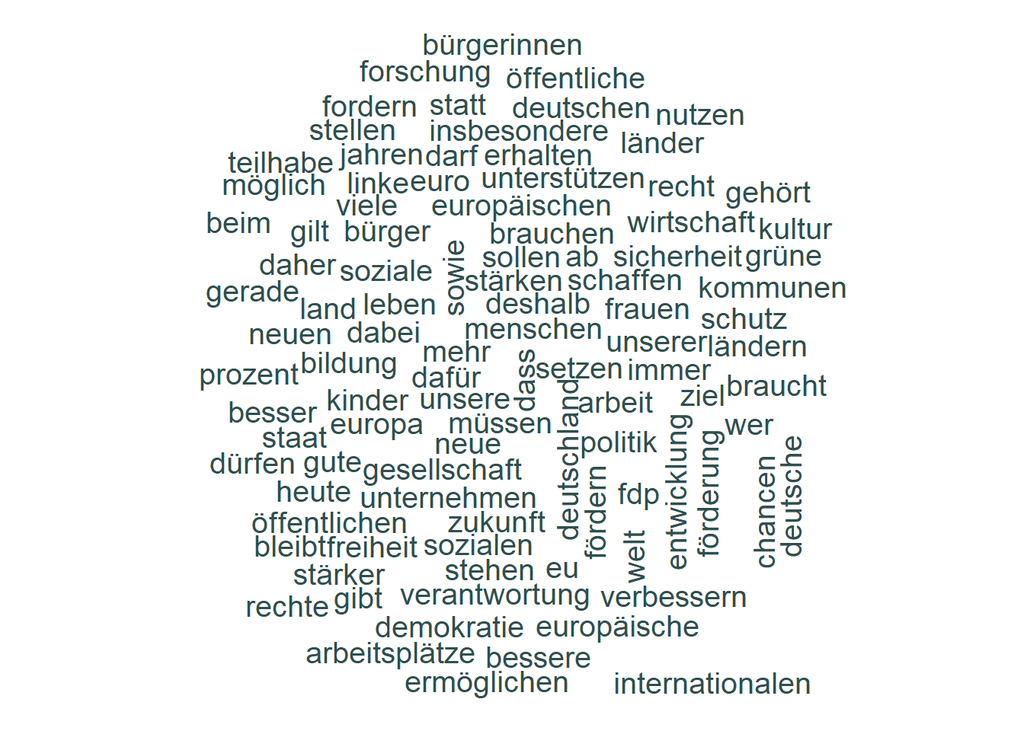

```r
set.seed(2021)
# word cloud for whole corpus
textplot_wordcloud(program_dfm, max_words = 100, min_size = 1.7, color = "darkslategrey")
```

Die Funktion `texplot_wordcloud` besitzt einen optionalen Parameter `comparison`, der es erlaubt, vergleichende Wortwolken zu erstellen. Dabei werden für eine Gruppe die Token ausgewählt, die im Vergleich zu den anderen Gruppen häufig vorkommen. Genaueres ist [hier in der Dokumentation](https://www.rdocumentation.org/packages/wordcloud/versions/2.6/topics/comparison.cloud) nachlesbar. So wurden vergleichende Wortwolken für die verschiedenen Parteien und die Jahre erstellt.

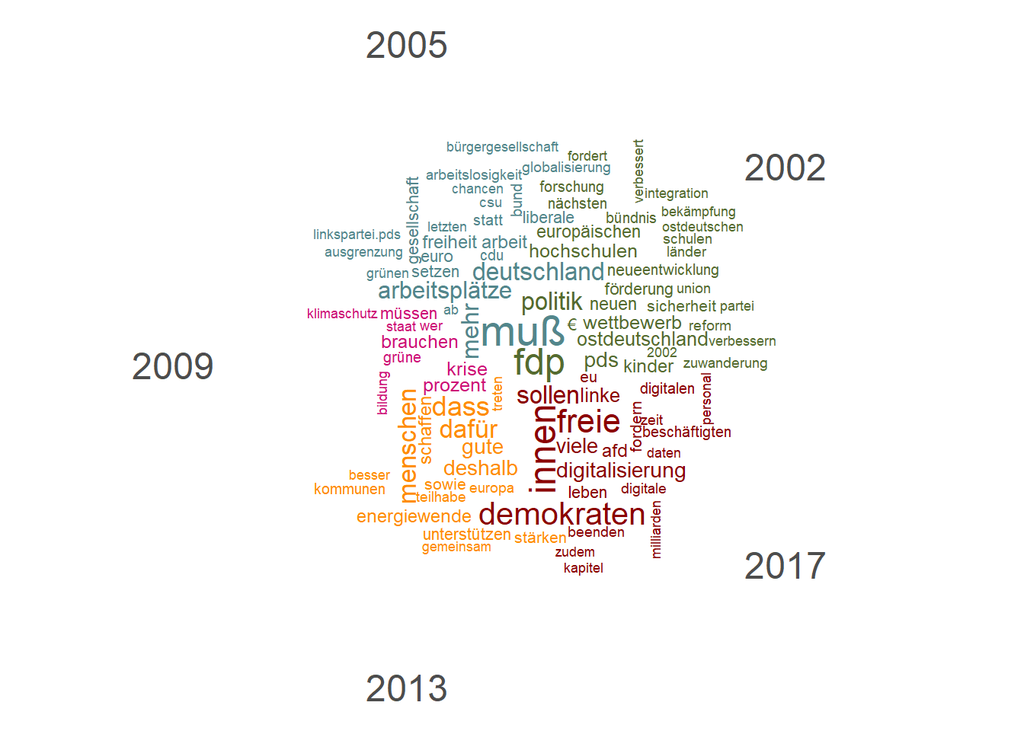

```r
years <- dfm(program_toks, groups = "year")
textplot_wordcloud(years, max_words = 100, min_size = 0.5, comparison=TRUE, color=c("darkolivegreen", "cadetblue4", "deeppink3", "darkorange", "darkred"))
```

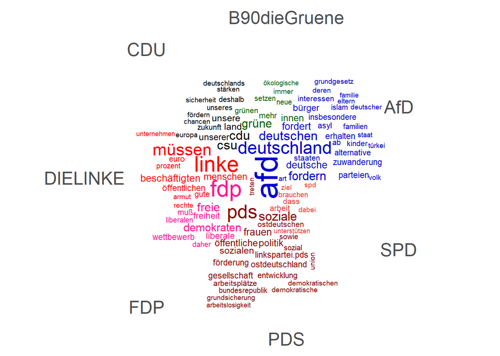

```r
parties <- dfm(program_toks, groups = "party")
textplot_wordcloud(parties, max_words = 100, min_size = 0.5, comparison=TRUE, color=c("blue3", "darkgreen", "black", "red", "deeppink", "darkred", "brown2"))
```

## Keywords in Context

Mit der `kwic`-Funktion können Token ausgegeben werden, die zusammen mit einem oder mehreren Schlüsselwörtern in einem bestimmten Fenster auftreten. Für das Schlüsselwort `deutsch*` - Der Asterix steht dabei für beliebige Folgezeichen - sieht der Rückgabewert etwa folgendermaßen aus:

```r
head(kwic(program_toks,"deutsch*", window=2))
```

```
##
##    [Bundestagswahl-AfD-2013.txt, 3]            Alternative | Deutschland |  fordern
##   [Bundestagswahl-AfD-2013.txt, 11]  Euro-Währungsgebietes | Deutschland | braucht
##   [Bundestagswahl-AfD-2013.txt, 70]           fordern dass | Deutschland |  Austrittsrecht
##  [Bundestagswahl-AfD-2013.txt, 205]            Alternative | Deutschland |
##  [Bundestagswahl-AfD-2013.txt, 267]            Alternative | Deutschland | Rechtsstaatlichkeit
##  [Bundestagswahl-AfD-2013.txt, 306]                Handeln |  deutschen  | Regierung findet
```

Auch aus dem Rückgabewert der `kwic`- Funktion lassen sich Wortwolken erstellen, die zeigen, mit welchen Token die Schlüsselwörter am häufigsten gemeinsam auftreten. So wird hier ein kleines Wörterbuch für das Thema (`umwelt*`, `klima*`, `nachhalt*`) Klima und Europa (`eu*`, `europ*`) erstellt, Kontextwörter in einem Fenster von 10 Token mithilfe der `kwic`-Funktion ermittelt und diese dann durch `texplot_wordcloud` veranschaulicht.

[figure not shown]

```r
# climate change dictionary
climate_dict <- c("klima*", "umwelt*", "nachhalt*")

# Word cloud for climate change dictionary
klima <- kwic(program_toks,climate_dict, window=10)
textplot_wordcloud(klima %>% corpus() %>% dfm(), max_words = 100, color= "chartreuse4")
```

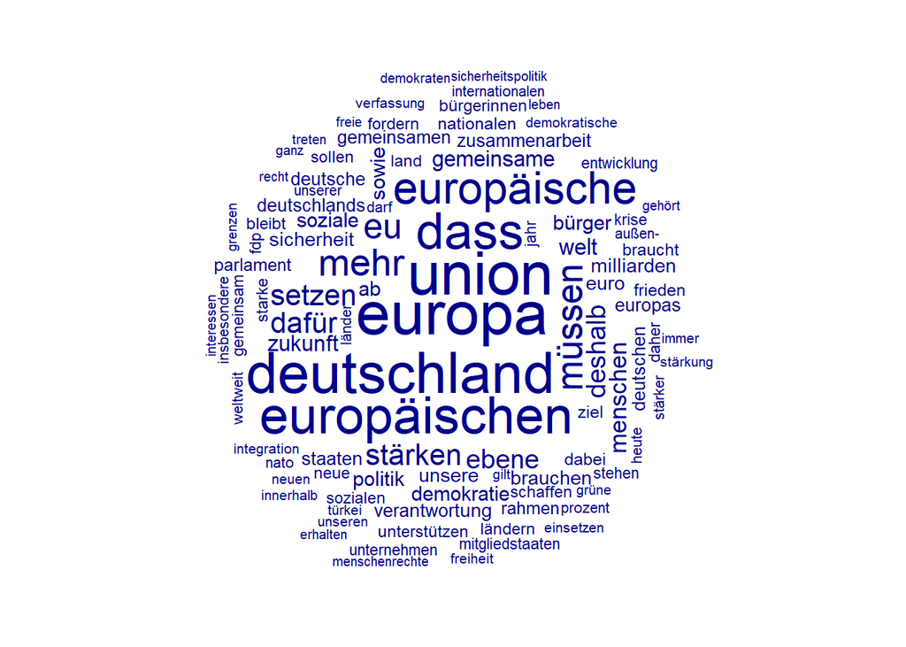

```r
# eu dictionary
eu_dict <- c("eu*", "europ*")

# Word cloud for climate change dictionary
eu <- kwic(program_toks,eu_dict, window=10)
textplot_wordcloud(eu%>% corpus() %>% dfm(), max_words = 100)
```

### Lexcial Dispersion

Aus `kwic`- Objekten lassen sich zudem Plots erstellen, die zeigen wie die Schlüsselwörter in den Dokumenten verteilt sind. Dafür werden die gleichen `kwic`-Objekte `klima` und `eu` verwendet.

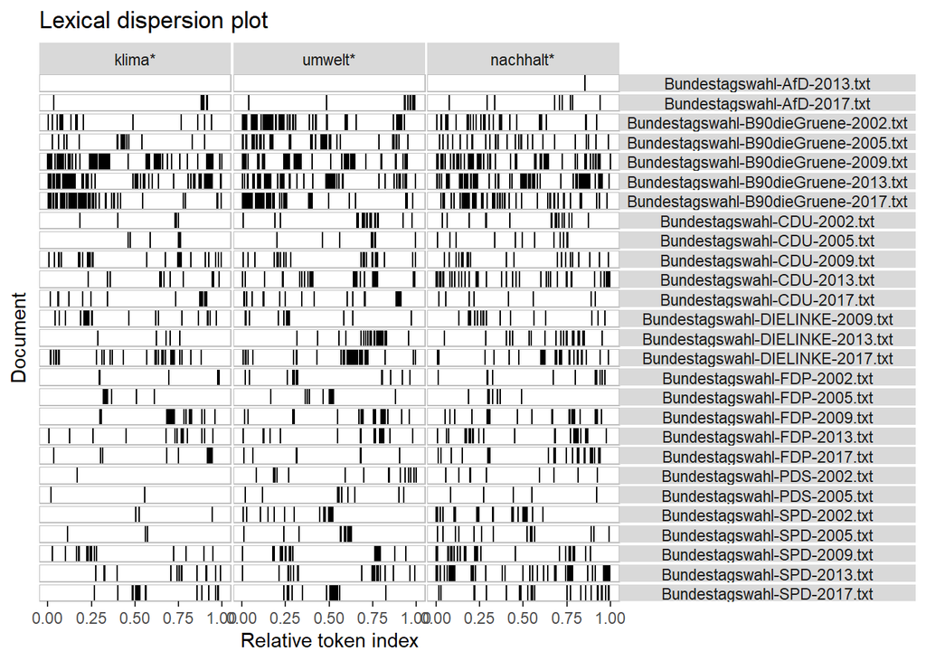

```r
textplot_xray(klima)
```

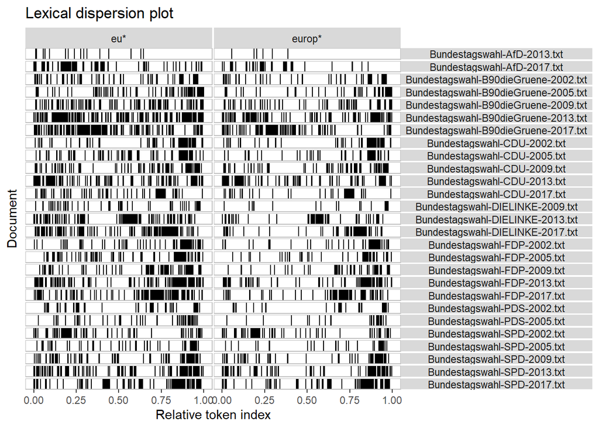

```r
textplot_xray(eu)
```

## Kollokationen

Mithilfe der Funktion `textstat_collocations` lassen sich häufige Bigramme im Korpus bestimmen. Zunächst werden häufige Bigramme in Korpus bestimmt, wobei Stoppwörter herausgefiltert worden sind:

```r
textstat_collocations(program_toks, min_count = 100)
```

```
##              collocation count count_nested length    lambda        z
## 1     europäischen union   182            0      2  6.932953 64.18573
## 2           unserem land   187            0      2  7.539477 64.07973
## 3   unserer gesellschaft   202            0      2  5.371442 63.18860
## 4         darüber hinaus   204            0      2 10.206276 58.67475
## 5           dafür sorgen   153            0      2  5.723266 55.01225
## 6         unseres landes   150            0      2  9.469491 54.45065
## 7      europäische union   108            0      2  6.549937 53.55605
## 8        milliarden euro   160            0      2  8.379288 52.17594
## 9            gute arbeit   131            0      2  5.225153 51.50236
## 10            immer mehr   167            0      2  4.300149 48.88740
## 11           sorgen dass   157            0      2  4.949452 48.66833
## 12        junge menschen   138            0      2  5.773785 46.21915
## 13 erneuerbaren energien   146            0      2 10.245926 43.74457
## 14        viele menschen   125            0      2  4.239690 41.89527
## 15      freie demokraten   252            0      2 11.531428 38.42149
## 16            dafür dass   140            0      2  3.104162 34.55200
## 17    vereinten nationen   193            0      2 14.069824 29.24672
## 18         mehr menschen   100            0      2  2.383825 23.06899
```

Auch mit Stoppwörtern können interessante Bigramme bebobachtet werden.

```r
textstat_collocations(programs, min_count = 500)
```

```
##       collocation count count_nested length     lambda          z
## 1      wir wollen  3700            0      2  4.0988752 159.611798
## 2      wollen wir  2781            0      2  4.4450581 158.097523
## 3         für die  2680            0      2  2.1517658  94.805353
## 4  in deutschland  1171            0      2  4.1785124  94.195580
## 5      werden wir  1086            0      2  3.4611225  93.329783
## 6          in der  2781            0      2  2.0624538  92.693245
## 7          in den  1718            0      2  2.5841344  91.284998
## 8      setzen uns   522            0      2  5.6365846  90.566746
## 9        für alle   875            0      2  3.9609056  81.845581
## 10       für eine  1309            0      2  2.4998997  78.553068
## 11        bei der  1042            0      2  2.8689506  72.709620
## 12        mit dem   518            0      2  3.4579736  67.812473
## 13     wir setzen   610            0      2  3.6442665  64.647007
## 14        für uns   505            0      2  2.6006150  51.330768
```

[output cut: 20 more lines]

## TF-IDF

Mithilfe von Term-Frequency und Inverted-Document-Frequency lassen sich Terme bestimmen, die für ein Dokument charakteristisch sind. Der Ausgabewert von `dfm_tfidf` ist eine Document-Feature-Matrix, sodass mit den Funktionen `dfm_subset` und `topfeatures` Terme ausgeben werden können, die besonders charakteristisch für eine bestimmte Gruppe sind. Im Folgenden sind auf diese Art kennzeichnende Begriffe für die einzelnen Parteien bestimmt worden:

```r
tfidf <- dfm_tfidf(program_toks %>% dfm(groups = "party"))
topfeatures(tfidf[1,])
```

```
##                         afd            gender-ideologie sozialversicherungsabkommen
##                   40.109470                    5.915686                    5.070588
##        parteienfinanzierung           volkssouveränität              ämterpatronage
##                    3.808476                    3.380392                    3.380392
##              parlamentarier            gender-forschung           deutsch-türkische
##                    3.380392                    3.380392                    3.380392
##                kultursorten
##                    3.380392
```

```r
# Distinctive terms for each party
afd <- dfm_subset(tfidf, tfidf$"party"=="AfD")
topfeatures(afd, n=10)
```

```
##                         afd            gender-ideologie sozialversicherungsabkommen
##                   40.109470                    5.915686                    5.070588
##        parteienfinanzierung           volkssouveränität              ämterpatronage
##                    3.808476                    3.380392                    3.380392
##              parlamentarier            gender-forschung           deutsch-türkische
##                    3.380392                    3.380392                    3.380392
##                kultursorten
##                    3.380392
```

```r
spd <- dfm_subset(tfidf, tfidf$"party"=="SPD")
topfeatures(spd, n=10)
```

```
## sozialdemokratinnen sozialdemokratische             gerhard    sozialdemokraten                   \200
##           27.888235           17.747059           16.322041           12.879187           11.039304
##       bundeskanzler       innen-projekt       bürgerkonvent     marktwirtschaft        solidarrente
##            9.567396            9.296078            9.296078            8.913810            8.450980
```

```r
cdu <- dfm_subset(tfidf, tfidf$"party"=="CDU")
topfeatures(cdu, n=10)
```

```
##                    cdu                    csu              schöpfung        zukunftsprojekt
##              17.740899              17.607006              12.676471              12.676471
##            mittelstand          verantwortung     heimatvertriebenen     bevölkerungswandel
##               9.059938               8.703083               8.450980               8.450980
## zuwanderungsgeschichte              vertrauen
##               8.450980               8.183170
```

```r
linke <- dfm_subset(tfidf, tfidf$"party"=="DIELINKE")
topfeatures(linke, n=10)
```

```
##                   linke                     vgl  massenerwerbslosigkeit gesundheitsversicherung
##                66.04987                33.18815                14.36667                14.36667
##        mindestsicherung                 kapitel                 profite        erwerbslosigkeit
##                14.14577                14.09621                13.05763                12.51121
##            erwerbslosen                   1.050
##                11.96950                11.83137
```

```r
gruene <- dfm_subset(tfidf, tfidf$"party"=="B90dieGruene")
topfeatures(gruene, n=10)
```

```
##                 grün                innen                wählt gesellschaftsvertrag
##             94.65098             47.49161             31.64600             30.42353
##                grüne        garantierente    massentierhaltung         schwarz-gelb
##             29.92521             24.50784             22.81765             19.04238
##           einmischen                green
##             16.55896             15.77797
```

```r
fdp <- dfm_subset(tfidf, tfidf$"party"=="FDP")
topfeatures(fdp, n=10)
```

```
##                          muß                          fdp                     liberale
##                    118.31373                    100.97447                     90.85936
##                   demokraten                   bürgergeld                    liberalen
##                     63.67597                     32.95882                     30.13672
##                    weltbeste              marktwirtschaft verantwortungsgemeinschaften
##                     24.50784                     13.73604                     10.98627
##           bürgergesellschaft
##                     10.20760
```

```r
pds <- dfm_subset(tfidf, tfidf$"party"=="PDS")
topfeatures(pds, n=10)
```

```
##                          pds              linkspartei.pds zukunftsinvestitionsprogramm
##                    27.966236                    18.592157                     3.380392
##           bedarfsorientierte                  umweltunion                     pluralen
##                     3.264408                     2.535294                     2.535294
##             rüstungsausgaben                    neuansatz       beschäftigungssektoren
##                     2.535294                     2.535294                     2.535294
##                  linkspartei
##                     2.207861
```

Mit dem gleichen Verfahren sind distinktive Begriffe für die einzelnen Jahren bestimmt worden:

```r
# Distinctive terms for each year
tfidf_year <- dfm_tfidf(program_toks %>% dfm(groups = "year"))

year_2002 <- dfm_subset(tfidf_year, tfidf_year$"year"==2002)
topfeatures(year_2002, n=20)
```

```
##                          pds                            \200               osterweiterung
##                    28.651681                    10.426891                     6.367040
##                   cyberspace                 rentenreform            eu-osterweiterung
##                     5.591760                     4.377340                     4.377340
##            arbeitslosenhilfe                         2003                         2004
##                     4.377340                     4.215126                     3.771429
##            gesamtdeutschland                 bildungstest          bildungsgutscheinen
##                     3.494850                     3.494850                     3.494850
##             welthandelsrunde                 südosteuropa arbeitsbeschaffungsmaßnahmen
##                     3.494850                     3.183520                     3.183520
##                  kinderkasse              beitrittsländer                   diagnostik
##                     2.795880                     2.795880                     2.795880
##                arbeitsfähige         ausbildungsordnungen
##                     2.795880                     2.795880
```

```r
year_2005 <- dfm_subset(tfidf_year, tfidf_year$"year"==2005)
topfeatures(year_2005, n=20)
```

```
##                          muß              linkspartei.pds                 steuerbürger
##                     97.85580                     15.37734                      4.19382
##            gesundheitsprämie                          pds                   respektlos
##                      3.97940                      3.58146                      2.79588
##                   feiertags-      kindergrundfreibetrages             teilzeitanspruch
##                      2.79588                      2.79588                      2.79588
##                      einfluß                  allgemeinem zukunftsinvestitionsprogramm
##                      2.79588                      2.79588                      2.79588
##           verfassungsvertrag           bürgergesellschaft                     rot-grün
##                      2.78558                      2.51966                      2.42275
##           bürgerversicherung            einkommensbereich                kopfpauschale
##                      2.42275                      2.38764                      2.38764
##              ausbildungspakt                     eu-recht
##                      2.38764                      2.38764
```

```r
year_2009 <- dfm_subset(tfidf_year, tfidf_year$"year"==2009)
topfeatures(year_2009, n=20)
```

```
##  gesellschaftsvertrag                 linke      wirtschaftskrise      mindesteinkommen
##             25.162920              8.334261              6.655462              6.290730
##       zukunftsprojekt                  deal          bildungssoli                    be
##              5.571160              5.324370              4.892790              4.892790
##                 green       beziehungsweise gesellschaftsvertrags                klima-
##              4.436975              4.436975              4.193820              3.993277
##                 wählt     kreativwirtschaft    börsenumsatzsteuer     konjunkturpolitik
##              3.779491              3.771429              3.581460              3.494850
##                barack      progressivmodell  laufzeitverlängerung              geduldet
##              3.494850              3.494850              3.494850              3.494850
```

```r
year_2013 <- dfm_subset(tfidf_year, tfidf_year$"year"==2013)
topfeatures(year_2013, n=20)
```

```
##                    linke        schlüsselprojekte                     2014         stabilitätsunion
##                17.346892                11.882490                 9.152620                 9.086610
##            innen-projekt            bürgerkonvent finanztransaktionssteuer            schuldenkrise
##                 7.688670                 7.688670                 7.162920                 6.989700
##       bevölkerungswandel   zuwanderungsgeschichte                inklusion               leiharbeit
##                 6.989700                 6.989700                 6.655462                 6.211765
##         geschäftsmodelle        kreativwirtschaft                        |    menschenfeindlichkeit
##                 5.969100                 5.768067                 5.591760                 5.571160
##           schuldenbremse             urheberinnen            schwarz-gelbe             währungsraum
##                 5.546219                 5.324370                 5.173220                 4.892790
```

```r
year_2017 <- dfm_subset(tfidf_year, tfidf_year$"year"==2017)
topfeatures(year_2017, n=20)
```

```
##               afd       geflüchtete               vgl         weltbeste             linke
##         78.284640         32.152620         22.682580         20.270130         18.800543
##              ceta             paris             trans      geflüchteten              ttip
##         11.882490         11.183520         11.183520         11.142320         10.484550
##         digitaler   mietpreisbremse              2016    schuldenbremse           pariser
##          9.152620          9.086610          8.356740          7.764706          7.688670
##            lsbtiq       dauerstress        fluchtwege innenversicherung   familien-budget
##          7.688670          7.688670          6.989700          6.989700          6.989700
```

## Topic Modelling

Um Topic Models zu erstellen, muss aus einer DFM ein LDA-Objekt erstellt werden (“Latent Dirichlet Allocation”). Über terms() kann man die Topics abrufen.

```r
program_lda_k10 <- textmodel_lda(program_dfm, k=10)
terms(program_lda_k10)
```

```
##       topic1         topic2        topic3                topic4        topic5
##  [1,] "deutschland"  "fdp"         "spd"                 "afd"         "ostdeutschland"
##  [2,] "cdu"          "liberale"    "arbeitnehmerinnen"   "deutschen"   "politik"
##  [3,] "csu"          "muß"         "verbraucherinnen"    "fordert"     "pds"
##  [4,] "land"         "wettbewerb"  "marktwirtschaft"     "zuwanderung" "bündnis"
##  [5,] "unserer"      "liberalen"   "sozialdemokraten"    "deutsche"    "globalisierung"
##  [6,] "chancen"      "setzt"       "mitbestimmung"       "lehnt"       "ostdeutschen"
##  [7,] "unsere"       "freiheit"    "sozialdemokratinnen" "parteien"    "\200"
##  [8,] "unseres"      "fordert"     "fortsetzen"          "fordern"     "arbeitslosigkeit"
##  [9,] "wachstum"     "staat"       "industriepolitik"    "deutscher"   "reform"
## [10,] "deutschlands" "hochschulen" "idee"                "alternative" "erneuerung"
##       topic6          topic7            topic8        topic9            topic10
##  [1,] "linke"         "freie"           ""            "innen"           "grüne"
##  [2,] "müssen"        "demokraten"      "dass"        "grüne"           "grünen"
##  [3,] "öffentliche"   "fordern"         "menschen"    "digitalisierung" "ökologischen"
##  [4,] "beschäftigten" "digitalisierung" "mehr"        "gutes"           "verbraucherinnen"
##  [5,] "soziale"       "daher"           "müssen"      "geflüchtete"     "grün"
##  [6,] "öffentlichen"  "daten"           "deutschland" "sorgen"          "ökologische"
##  [7,] "euro"          "beispiel"        "dafür"       "kämpfen"         "teilhabe"
##  [8,] "statt"         "altersvorsorge"  "deshalb"     "drei"            "endlich"
##  [9,] "sozial"        "weltbeste"       "setzen"      "oft"             "wählt"
## [10,] "fordert"       "digitalen"       "stärken"     "viele"           "jobs"
```

Für die einzelnen Parteien wie folgt (hier nur exemplarisch, da sich keine all zu aussagekräftigen Ergebnisse gezeigt haben):

```r
# topics from B90/Die Grüne programs
gruene_lda_k20 <- textmodel_lda(dfm(programs[programs$party == "B90dieGruene"], remove_punct=TRUE, remove=(stopwords("german"))), k=20)
terms(gruene_lda_k20)
```

```
##       topic1                     topic2             topic3             topic4
##  [1,] "informieren"              "täterinnen"       "bestrafung"       "einmischen"
##  [2,] "10"                       "verwendet"        "2014"             "mrd"
##  [3,] "hektar"                   "geschieht"        "langsam"          "6"
##  [4,] "potential"                "ausbildungsplatz" "regelsätze"       "energiewende"
##  [5,] "finanzierungsinstrumente" "per"              "medizinisch"      "5"
##  [6,] "unterschiedlicher"        "fort"             "koordinierung"    "urheberinnen"
##  [7,] "herzustellen"             "substanz"         "neue"             "transformation"
##  [8,] "km"                       "erlangen"         "studien"          "teilhaben"
##  [9,] "chemische"                "u.a"              "ergebnis"         "altersarmut"
## [10,] "kultureinrichtungen"      "reich"            "betriebsvermögen" "schlüsselprojekte"
##       topic5                  topic6        topic7                   topic8
##  [1,] "mindestlohns"          "ecke"        "steuerzahlerinnen"      "innen"
##  [2,] "gleichzeitig"          "potenzial"   "prioritäten"            "digitalisierung"
##  [3,] "holen"                 "öpnv"        "akteuren"               "projekte"
```

[output cut: 40 more lines]